# Assignment 3 - SED Fitting

## Bayesian Statistics

**Completed By**: Justin Marchioni

**Date**: Mar. 28$^\textrm{th}$, 2024

This assignment is split into 3 sections, roughly corresponding to the contents of each of the 3 weeks in the Bayesian Statistics module.

All assignments are presented as Jupyter notebooks. You will fork the repository to have your own access to all files. You can edit this notebook directly with your answers and push your changes to GitHub.

### **The goal of this assignment is to use different MCMC and Bayesian inference techniques to fit SEDs to galaxy magnitudes**

# STEP 0 - Prospector Inputs

Prospector has some in-built MCMC techniques that you will have used in Assignment 1 (Emcee or Dynesty). For this assignment you will not be using these in-built tools, instead you will use external libraries to code your own MCMC results and perform model comparisons on them. However, we will still use prospector for the model so lets prepare that here.

### The model we are using is a very simple parametric model with 6 free parameters

### $M_{\rm star}$ stellar mass

### $\log(z_{\rm sol})$ metallicity?

### dust V-band optical depth

### $t_{\rm age}$ The age of the host galaxy

### $\tau$

1. Activate the enviroment/kernel you used with prospector installed
2. Prepare the prospector model (if you like you can edit the below model, but you dont have to)

```python
from prospect.models import SedModel, priors
from prospect.models.templates import TemplateLibrary
from prospect.sources import CSPSpecBasis
import time

model_params = TemplateLibrary["parametric_sfh"]

# Let redshift vary
model_params["zred"]["isfree"] = True
model_params['zred']['init'] = 0.1
model_params['zred']['prior'] = priors.TopHat(mini=0,maxi=1)

# Build the model
prospector_model = SedModel(model_params)

sps = CSPSpecBasis(zcontinuous=1)
```

3. Load the data vector for a given galaxy (again you can change the galaxy if you wish, maybe match one of your galaxies from assignment 1)

```python
import sedpy
import prospect
import numpy as np
import pandas as pd
from astropy.io import fits
from astropy.table import Table

# Set the table index of the galaxy
# Note: this is different from "id" in the table
gal_id = 345591

with fits.open('../data/sw_input.fits') as f:
    df = Table(f[1].data).to_pandas()
    f.close()

def build_obs(gal_id):
    """Given an object, load in fluxes, convert them to nanomaggies, and create a dict used in Prospector."""

    inp = {}

    # Get dataframe row for the object
    row = df.iloc[gal_id]
    inp['redshift'] = row.redshift

    # Load the filter response curves from sedpy
    bands = [f'sdss_{filt}0' for filt in 'ugriz'] + [f'wise_w{n}' for n in range(1,5)]
    filters = sedpy.observate.load_filters(bands)
    inp['filters'] = filters

    # Fluxes and uncertainties - already in units of maggies
    cols = [f'flux_{filt}' for filt in 'ugriz'] + [f'flux_w{n}' for n in range(1,5)]
    fluxes = row[cols].values.astype(float) / 3631

    # Errors
    cols_err = [f'{col}_e' for col in cols]
    errs = row[cols_err].values.astype(float) / 3631

    # Anything with a value of 9.999 is null, so may need to mask those fluxes by editing phot_mask
    inp['maggies'] = fluxes
    inp['maggies_unc'] = errs
    inp['phot_mask'] = [True for val in fluxes] # Nothing masked here right now

    # This is an array of effective wavelengths for each of the filters.
    # It is not necessary, but it can be useful for plotting so we store it here as a convenience
    inp["phot_wave"] = np.array([f.wave_effective for f in inp["filters"]])
    inp["wavelength"] = None

    # Populate other fields with default
    inp = prospect.utils.obsutils.fix_obs(inp)
    return inp

obs = build_obs(gal_id)
```

4. Prepare a function that takes the 6 parameters as input, and outputs the predicted fluxes in maggies (once this is set up, you shouldn't have to use prospector directly again for this assignment)

```python
# A random sample from Prospectors default priors (just to make sure the model runs)
random_input_values = np.array([model_params[k]['prior'].sample()[0] for k in model_params.keys() if model_params[k]['isfree']==True])
param_names = np.array([model_params[k]['name'] for k in model_params.keys() if model_params[k]['isfree']==True])
print('Parameters should enter the function in this order:')
print(param_names)

### THIS IS THE FUNCTION YOU CAN USE FOR ALL
### YOUR MODEL PREDICTIONS FROM THIS POINT
def model(theta):
    return prospector_model.predict(theta, obs=obs, sps=sps)[1]
```

```
Parameters should enter the function in this order:
['zred' 'mass' 'logzsol' 'dust2' 'tage' 'tau']
```

5. Prospector does some kind of caching under the hood such that the calls to the model that require uncached inputs take much longer than the cached ones

We can get around this by initially running the model at enough random parameter inputs to cover all of the possible cached file we will need (there is very likely a better way to do this)

Try to avoid calling the model with inputs outside of the range defined below

THIS LINE WILL TAKE A COUPLE MINUTES TO RUN

```python
import scipy.stats
np.random.seed(1)

nsamples = 10

#prior boundaries
zred_min = 0.0
zred_max = 1.0
logmass_min = 8.0
logmass_max = 12.0
logzsol_min = -2.0
logzsol_max = 0.19
dust2_min = 0.0
dust2_max = 2.0
tage_min = 0.001
tage_max = 13.8
logtau_min = np.log10(0.1)
logtau_max = np.log10(30)
theta_min = np.array([zred_min, logmass_min, logzsol_min, dust2_min, tage_min, logtau_min])
theta_max = np.array([zred_max, logmass_max, logzsol_max, dust2_max, tage_max, logtau_max])

#generate some random input parameter combos
lhc_sampling = scipy.stats.qmc.LatinHypercube(6)
input_params = theta_min + lhc_sampling.random(nsamples) * (theta_max-theta_min)
#un-log the mass and tau
input_params[:,1] = 10.**input_params[:,1]
input_params[:,5] = 10.**input_params[:,5]

model_evals = np.zeros( (nsamples, obs['ndof']) )
for i in range(nsamples):
    start = time.time()
    model_evals[i] = model(input_params[i])
    finish = time.time()
    print(i, f'{finish-start}s')
```

```
0 28.725261688232422s
1 14.627148628234863s
2 0.004491567611694336s
3 30.23954439163208s
4 14.483001708984375s
5 14.649872779846191s
6 0.00553131103515625s
7 15.697443962097168s
8 14.302544355392456s
9 16.753244161605835s
```

# SECTION 1 - MCMC

1. Pick (and install) your 2 favourite MCMC sampling methods/implementations you learned about in the lectures (At least 1 of them should be a "nested" sampling method, as we will use the features of nested sampling later)

Some examples are shown below

#### Metropolis-Hastings and Gibbs sampling

- The most famous sampling methods
- Many people code their own versions
- There are many examples and packages online to do this (some examples we haven't tested [here](https://github.com/WenjieZ/easyMH) [here](https://pymcmcstat.readthedocs.io/en/latest/#pymcmcstat) [here](https://numeryst.com/gibbs-sampling-an-introduction-with-python-implementation/#Code_Example))

#### Ensemble

- More sophisticated samplers
- Affine-invariant [EMCEE](https://emcee.readthedocs.io/en/stable/)
- KDE [Kombine](https://github.com/bfarr/kombine)

#### Nested sampling

- [Multinest](https://github.com/rjw57/MultiNest)
- [Polychord](https://github.com/PolyChord/PolyChordLite)
- [Dynesty](https://dynesty.readthedocs.io/en/latest/index.html) (Has some really great documentation)

#### Other

- [Nautilus](https://nautilus-sampler.readthedocs.io/en/stable/)

```python
# Import Libraries
import matplotlib
import matplotlib.pyplot as plt
import matplotlib.ticker as ticker

# Import Sampling Methods
import emcee as emcee        # EMCEE
import dynesty as dynesty    # Dynesty

# Adjust default font size so that labels are readable in plots
font = {'size': 16}
matplotlib.rc('font', **font)
matplotlib.rcParams['savefig.dpi'] = 120
matplotlib.rcParams['figure.dpi'] = 120
matplotlib.rcParams['figure.figsize'] = [6, 4]
matplotlib.rcParams['mathtext.fontset'] = 'cm'
matplotlib.rcParams['font.family'] = 'STIXGeneral'
```

2. Fit your model to your data using your 2 chosen sampling techniques
- Choose flat top-hat priors for all parameters (you can look at your results from Assignment 1 to get some reasonable ranges)
- Plot the resulting parameter constraints on top of each other. e.g. in a corner plot
- Do they agree with each other?

From Bayes' Rule, the posterior probability function (up to a constant) is given by:

$$ p(\vec{\theta}|x_i, y_i) \propto p(\vec{\theta}) p(y_i| x_i, \vec{\theta}) $$

where $\vec{\theta}$ is a vector of the model parameters. In the above expression, $p(\vec{\theta})$ is the prior and $p(y_i| x_i, \vec{\theta})$ is the likelihood, both of which depend on the model. Furthermore, in our case we will assume that the prior we have is uniform and that the model parameters are independent. In this case, the prior probability is:

$$ p(\vec{\theta}) = \prod_{i = 1}^{n} p(\theta_i) $$

where $\theta_i$ are each of the $n$ model parameters with uniform probability:

$$ p(\theta_i) = \begin{cases} \frac{1}{b-a}, & a \leq \theta_i \leq b \\ 0, & \textrm{otherwise} \end{cases} $$

where $a$ and $b$ are the lower and upper limits, respectively, on the possible values for $\theta_i$.

Suppose we wanted to fit a model of the form $y(x, \vec{\theta})$. If we assume each observed $y_i$ has Gaussian uncertainties with mean $y(x_i, \vec{\theta})$ and uncertainty $\sigma_i$, then the probability of observing $y_i$ given $x_i$ and the model parameters $\vec{\theta}$ is then:

$$ p(y_i|x_i, \vec{\theta}) = \frac{1}{\sqrt{2\pi}\sigma_i}\exp\left(-\frac{\left[y_i-y(x_i, \vec{\theta})\right]^2}{2\sigma_i^2}\right) $$

If we have $N$ observations, then the total probability is given by the likelihood function.

$$ {\cal L}(y_1, \ldots y_n|x_i, \ldots x_n, \vec{\theta}) = \prod_i^N p(y_i|x_i, \vec{\theta}) $$

Putting this all together, for our model the posterior probability function is then:

$$ p(\vec{\theta}|x_i, y_i) \propto \prod_{i = 1}^{n} p(\theta_i) \prod_i^N \frac{1}{\sqrt{2\pi}\sigma_i}\exp\left(-\frac{\left[y_i-y(x_i, \vec{\theta})\right]^2}{2\sigma_i^2}\right) $$

However, if $N$ is too large then the value of $p(\vec{\theta}|x_i, y_i)$ could be smaller than the smallest float value that can be stored in Python. Thus, we will look at the $\ln$ of the posterior distribution.

$$ \ln p(\vec{\theta}|x_i, y_i) \propto \ln \left[ \prod_{i = 1}^{n} p(\theta_i) \prod_i^N \frac{1}{\sqrt{2\pi}\sigma_i}\exp\left(-\frac{\left[y_i-y(x_i, \vec{\theta})\right]^2}{2\sigma_i^2}\right) \right] $$$$ \ln p(\vec{\theta}|x_i, y_i) \propto \sum_{i = 1}^{n} \ln p(\theta_i) + \sum_i^N \ln\left[ \frac{1}{\sqrt{2\pi}\sigma_i}\exp\left(-\frac{\left[y_i-y(x_i, \vec{\theta})\right]^2}{2\sigma_i^2}\right) \right] $$$$ \ln p(\vec{\theta}|x_i, y_i) \propto \sum_{i = 1}^{n} \ln p(\theta_i) - \frac{N}{2} \ln(2\pi) - \sum_i^N \ln(\sigma_i) - \sum_i^N\frac{\left[y_i-y(x_i, \vec{\theta})\right]^2}{2\sigma_i^2} $$

$$$$

```python
# Set the number of walkers and steps
nwalkers = 32
ndim = 6
nsteps = 5000

# Set ranges for the different parameters
zred = np.array([0.01, 0.80])
logmass = np.array([8.5, 11.9])
logzsol = np.array([-1.6, 0.18])
dust2 = np.array([0.01, 1.5])
tage = np.array([0.01, 13.79])
logtau = np.array([-0.99, 1.45])

# Setup the overall parameter ranges
theta = np.zeros((nwalkers, ndim))
params_range = np.vstack((zred, logmass, logzsol, dust2, tage, logtau))

# Loop over each chain and model parameter to generate
# the initial values
# Note: We are using flat top-hat priors
for i in range(0, nwalkers):
    for j in range(0, ndim):
        theta[i, j] = np.random.uniform(low = params_range[j, 0], high = params_range[j, 1])
    # End of for loop
# End of for loop

# Un-log the mass and tau values
theta[:, 1] = 10**theta[:, 1]
theta[:, 5] = 10**theta[:, 5]
params_range[1] = 10**params_range[1]
params_range[5] = 10**params_range[5]
```

```python
## Posterior Distribution ##

# Define a function for the prior distributions
def log_prior(theta, a, b):
    if (a <= theta) & (theta <= b):
        return np.log(1 / (b - a))
    else:
        return -np.inf
# End of function definition

# Define a function for the posterior distribution
def posterior(theta, y, sigma, params_range):

    # Set the initial probability
    N = len(y)
    prob = 0.0

    # Loop over each parameter
    for i in range(0, len(theta)):
        prob += log_prior(theta[i], params_range[i, 0], params_range[i, 1])
    # End of for loop

    # If theta is outside the prior range
    if not np.isfinite(prob):
        return prob

    # Add the rest of the terms to the probability
    prob += -(N/2) * np.log(2*np.pi)
    prob += -np.sum( np.log(sigma) )
    prob += -np.sum( (y - model(theta))**2 / (2*sigma**2) )

    # Return the posterior distribution
    return prob

# End of function definition
```

```python
# Sampler 1: Emcee
sampler_Emcee = emcee.EnsembleSampler(nwalkers, ndim, posterior, args = [obs['maggies'], obs['maggies_unc'], params_range])
state_Emcee = sampler_Emcee.run_mcmc(theta, nsteps, progress = True)
```

```python
# Log the mass and tau values
theta[:, 1] = np.log10(theta[:, 1])
theta[:, 5] = np.log10(theta[:, 5])
params_range[1] = np.log10(params_range[1])
params_range[5] = np.log10(params_range[5])

# Define the prior transform for dynesty
def prior_transform(u):
    x = np.zeros(len(u))
    for i in range(0, len(u)):
        x[i] = params_range[i, 0] + (params_range[i, 1] - params_range[i, 0]) * u[i]
    return x
# End of function definition

# Define the likelihood function for dynesty
def loglike(x):

    # Get the number of observations
    N = len(obs['maggies'])

    # Un-log the mass and tau values
    x[1] = 10**x[1]
    x[5] = 10**x[5]

    # Calculate the log-likelihood
    prob = -(N/2)*np.log(2*np.pi) - np.sum(np.log(obs['maggies_unc'])) - np.sum((obs['maggies'] - model(x))**2/(2*obs['maggies_unc']**2) )

    # Return the probability
    return prob

# End of function definition
```

```python
# Sampler 2: Dynesty
sampler_Dyn = dynesty.NestedSampler(loglike, prior_transform, ndim, bootstrap = 0)
state_Dyn = sampler_Dyn.run_nested()
results_Dyn = sampler_Dyn.results
```

```
6296it [15:43,  6.67it/s, +500 | bound: 236 | nc: 1 | ncall: 195198 | eff(%):  3.491 | loglstar:   -inf < 150.299 <    inf | logz: 138.403 +/-  0.153 | dlogz:  0.001 >  0.509]
```

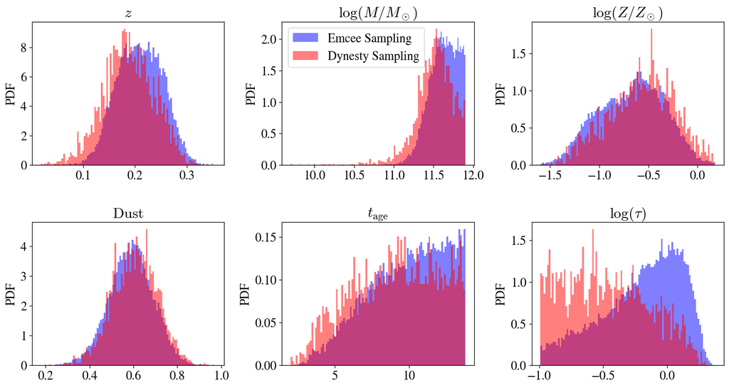

```python
# Extract the Emcee and Dynesty chains
# Note: Emcee has the burn-in removed
#       Dynesty results do not have burn-in by default
chains_Emcee = sampler_Emcee.get_chain(flat = True, discard = 300)
chains_Dyn = results_Dyn.samples_equal()

# Set titles for the plot below
labels = ['$z$', '$\\log(M/M_\\odot)$', '$\\log(Z/Z_\\odot)$', '${\\rm Dust}$', '$t_{\\rm age}$', '$\\log(\\tau)$']

# Plot a comparison of the distributions
fig = plt.figure(figsize = (16, 8))
gs = fig.add_gridspec(2, 3, wspace = 0.3, hspace = 0.4)

# Loop over each axis
t = 0
for i in range(0, 2):
    for j in range(0, 3):

        # Add an axis to the plot
        ax = fig.add_subplot(gs[i, j])

        # Get the data for the plot
        data_Emcee = chains_Emcee[:, t]
        data_Dyn = chains_Dyn[:, t]

        # If we are looking at mass or tau, log10 values
        if (i == 0) & (j == 1) | (i == 1) & (j == 2):
            data_Emcee = np.log10(data_Emcee)
            data_Dyn = data_Dyn
        # End of if

        # Add the title to the plot
        ax.title.set_text(labels[t])

        # Add the data to the plot
        ax.hist(data_Emcee, bins = 100, density = True, color = 'blue', alpha = 0.5, zorder = 1, label = 'Emcee Sampling')
        ax.hist(data_Dyn, bins = 100, density = True, color = 'red', alpha = 0.5, zorder = 1, label = 'Dynesty Sampling')

        # Add labels to the axes
        ax.set_ylabel('PDF')

        # Add a legend
        if (i == 0) & (j == 1):
            ax.legend()

        # Iterate to next values
        t += 1

    # End of for loop
# End of for loop
```

The figures above show the posterior distributions for the model parameters sampled using Emcee (Ensemble sampling) and Dynesty (Nested sampling). The Emcee results are shown in blue and the Dynesty results in red.

As seen above, a majority of the model parameter distributions agree between the two methods. The parameters for mass, metallicity, dust, and age have the most overlap. There is a small difference in the predicted redshifts where the center of the Emcee distribution is shifted slightly to larger redshifts. The largest difference in the methods is seen in the $\tau$ distributions. The Emcee distribution predicts a value of $\tau$ that is much larger than Dynesty, although the Dynesty distribution is quite broad. The Emcee distribution is likely more correct compared to Dynesty since the stopping criteria used for Dynesty is optimized to estimate the Bayesian evidence compared to the posteriors.

3. Did either of your sampling methods have a burn-in? if so make a plot showing the burn-in and justify how much burn-in to remove. If not, explain why there is no burn-in in your methods.

```python
# Define a function to plot the MCMC chains
def plot_chains(chain, title_label, yaxis_labels, fig_size, burn):

    # Get important parameters
    shape = chain.shape
    (nsteps, nwalkers, npars) = list(shape)

    # Generate the axes
    fig = plt.figure(figsize = (fig_size[0] * npars, fig_size[1] * 1))
    gs = fig.add_gridspec(1, npars, wspace = 0.30, hspace = 0.0)
    fig.suptitle('{0} Sampling'.format(title_label))

    # Loop over each axis
    for npar in range(npars):

        # Add an axis to the plot
        ax = fig.add_subplot(gs[0, npar])

        # Add each chain to the plot
        for nwalk in range(nwalkers):
            ax.plot(list(range(1, nsteps + 1)), chain[:, nwalk, npar], linestyle = 'solid', marker = 'None')
        # End of for loop

        ax.axvline(burn, color = 'black', linewidth = 4.0)
        ax.minorticks_on()
        ax.tick_params('both', length=8, width=1, which='major')
        ax.tick_params('both', length=5, width=1, which='minor')

        ax.set_xscale('log')
        ax.get_xaxis().set_major_formatter(ticker.ScalarFormatter())
        ax.xaxis.set_ticks_position('both')
        ax.xaxis.set_tick_params(direction='in', which='both')
        ax.set_xlabel('Step Number')

        ax.get_yaxis().set_major_formatter(ticker.ScalarFormatter())
        ax.yaxis.set_ticks_position('both')
        ax.yaxis.set_tick_params(direction='in', which='both')
        ax.set_ylabel('{0}'.format(yaxis_labels[npar]))

    # End of for loop

    plt.show()

# End of function definition
```

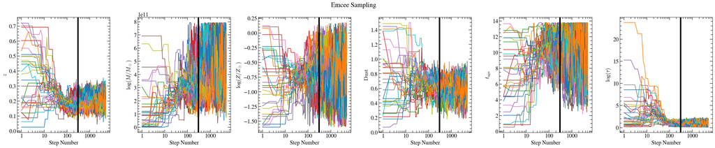

```python
# Plot the MCMC chains for Emcee
plot_chains(sampler_Emcee.get_chain(), 'Emcee', labels, [6.0, 6.0], burn = 300)
```

Sampling using Emcee resulted in burn-in as shown in the plots above. The black line illustrates the amount of burn-in removed from the chains in creating the posterior distribution plots for Emcee in the previous part (i.e., the posterior plots above). Here, we remove samples that are not exploring the important parts of the posterior distributions, ensuring enough samples are removed such that this is true for all model parameters.

Sampling using Dynesty did not result in burn-in. This method does not have burn-in since each sample that makes up the posterior distribution is weighted by an "importance weight". Unimportant points that would usually have a burn-in-like affect are weighted lowly. As a result, these samples do not contribute to the model posteriors.

# SECTION 2 - Model Comparison

1. Use the nested sampling technique you chose in Section 1 to compute the Bayesian Evidence of your model fit.

```python
# Extract the Bayesian evidence estimate
logZ = results_Dyn['logz'][-1]
logZ_err = results_Dyn['logzerr'][-1]

# Print the results
print('Dynesty estimate for the Bayesian evidence of our model fit:')
print('ln(Z) = {0} +/- {1}'.format(logZ, logZ_err))
```

```
Dynesty estimate for the Bayesian evidence of our model fit:
ln(Z) = 138.4032677397475 +/- 0.2593083956737533
```

2. Change the model in some-way and re-run your nested sampling chain (e.g. add/remove a new parameter, or dramatically change the prior on a parameter).

```python
# Extract the spectroscopic redshift for the galaxy
z_red = obs['redshift']

# Define the prospector model so that redshift is a fixed quantity
def model_z(theta, redshift):

    # Add redshift to the parameter vector
    params = np.array([redshift] + list(theta))

    # Return the model predictions
    return prospector_model.predict(params, obs=obs, sps=sps)[1]

# End of function definition

# Define the prior transform for dynesty
def prior_transform_z(u):
    x = np.zeros(len(u))
    for i in range(0, len(u)):
        x[i] = params_range[i + 1, 0] + (params_range[i + 1, 1] - params_range[i + 1, 0]) * u[i]
    return x
# End of function definition

# Define the likelihood function for dynesty
def loglike_z(x):

    # Get the number of observations
    N = len(obs['maggies'])

    # Un-log the mass and tau values
    x[0] = 10**x[0]
    x[4] = 10**x[4]

    # Calculate the log-likelihood
    prob = -(N/2)*np.log(2*np.pi) - np.sum(np.log(obs['maggies_unc'])) - np.sum((obs['maggies'] - model_z(x, z_red))**2/(2*obs['maggies_unc']**2) )

    # Return the probability
    return prob

# End of function definition
```

```python
# Sampler assuming fixed redshift: Dynesty
sampler_z_Dyn = dynesty.NestedSampler(loglike_z, prior_transform_z, ndim - 1, bootstrap = 0)
state_z_Dyn = sampler_z_Dyn.run_nested()
results_z_Dyn = sampler_z_Dyn.results
```

```
5404it [03:54, 23.05it/s, +500 | bound: 43 | nc: 1 | ncall: 50002 | eff(%): 11.927 | loglstar:   -inf < 150.333 <    inf | logz: 140.263 +/-  0.139 | dlogz:  0.001 >  0.509]
```

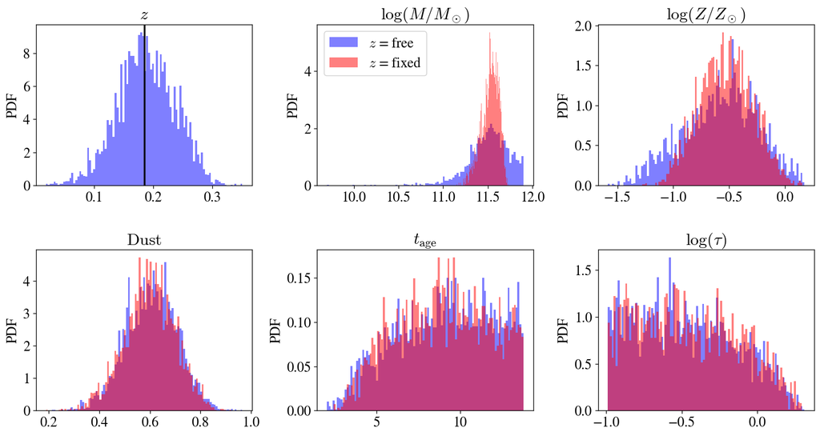

```python
# Extract the Dynesty samples for the fixed redshift distribution
chains_z_Dyn = results_z_Dyn.samples_equal()

# Set titles for the plot below
labels = ['$z$', '$\\log(M/M_\\odot)$', '$\\log(Z/Z_\\odot)$', '${\\rm Dust}$', '$t_{\\rm age}$', '$\\log(\\tau)$']

# Plot a comparison of the distributions varying and not varying redshift
fig = plt.figure(figsize = (16, 8))
gs = fig.add_gridspec(2, 3, wspace = 0.3, hspace = 0.4)

# Loop over each axis
t = 0
for i in range(0, 2):
    for j in range(0, 3):

        # Add an axis to the plot
        ax = fig.add_subplot(gs[i, j])

        # Get the data for the plot
        data_Dyn = chains_Dyn[:, t]
        data_z_Dyn = chains_z_Dyn[:, t - 1]

        # Add the title to the plot
        ax.title.set_text(labels[t])

        # Add the data to the plot
        if (i == 0) & (j == 0):
            ax.hist(data_Dyn, bins = 100, density = True, color = 'blue', alpha = 0.5, zorder = 1, label = '$z$ = free')
            ax.axvline(z_red, color = 'black', linewidth = 2.0)
        else:
            ax.hist(data_Dyn, bins = 100, density = True, color = 'blue', alpha = 0.5, zorder = 1, label = '$z$ = free')
            ax.hist(data_z_Dyn, bins = 100, density = True, color = 'red', alpha = 0.5, zorder = 1, label = '$z$ = fixed')
        # End of if

        # Add labels to the axes
        ax.set_ylabel('PDF')

        # Add a legend
        if (i == 0) & (j == 1):
            ax.legend()

        # Iterate to next values
        t += 1

    # End of for loop
# End of for loop
```

The figures above show the posterior distributions for the model parameters sampled using Dynesty assuming the redshift is either a fixed or free parameter. The free redshift results are shown in blue and the fixed redshift results are shown in red.

As seen above, only the mass and metallicity distributions are different between the runs. The fixed redshift distributions are thinner and more localized around the centers of the free redshift distributions indicating that limiting redshift to being a fixed parameter allows for better estimation of the other parameters. On the other hand, the dust, age, and $\tau$ distributions are extremely similar between the two runs. Between runs, these distributions overlap almost perfectly, indicating that redshift isn't as correlated with these parameters compared to mass and metallicity.

3. Use a Bayesian model comparison technique to decide which model your data prefer.

We will use the Bayes factor to compare models. For a given set of observed data $D$, the plausibility of two different models $M_1$ and $M_2$ is given by the Bayes factor:

$$ K = \frac{P(D|M_1)}{P(D|M_2)} = \frac{Z_1}{Z_2} $$

where $Z_1$ and $Z_2$ are the Bayesian evidence for models $M_1$ and $M_2$, respectively. A value of $K > 1$ indicates that $M_1$ is more strongly supported by the data compared to $M_2$.

```python
# Extract the Bayesian evidence estimate for the free redshift model
logZ_M1 = results_Dyn['logz'][-1]
logZ_err_M1 = results_Dyn['logzerr'][-1]

# Extract the Bayesian evidence estimate for the fixed redshift model
logZ_M2 = results_z_Dyn['logz'][-1]
logZ_err_M2 = results_z_Dyn['logzerr'][-1]

# Print the results
print('Dynesty estimate for the Bayesian evidence assuming free redshift:')
print('ln(Z1) = {0} +/- {1}'.format(logZ_M1, logZ_err_M1))
print('\n')
print('Dynesty estimate for the Bayesian evidence assuming fixed redshift:')
print('ln(Z2) = {0} +/- {1}'.format(logZ_M2, logZ_err_M2))
print('\n')

# Compute and print the Bayes factor to compare models
Bayes_K = np.exp(logZ_M2 - logZ_M1)
print('Bayes Factor for the models: {0}'.format(Bayes_K))
```

```
Dynesty estimate for the Bayesian evidence assuming free redshift:
ln(Z1) = 138.4032677397475 +/- 0.2593083956737533


Dynesty estimate for the Bayesian evidence assuming fixed redshift:
ln(Z2) = 140.2625668279153 +/- 0.24139514216633232


Bayes Factor for the models: 6.419235875868856
```

The Bayes factor provides a measure for the preference of the data for one model over another. According to the "Interpretation" section in the "Bayes Factor" Wikipedia article, a Bayes factor $K = [3.2, 10]$ indicates substantial evidence preferring one model over another. In this case, this means the data prefers the model where redshift is fixed over the model where redshift is a free parameter.

# SECTION 3 - Comparing results

1. How do the conclusions from your "Bayesian" model comparison compare to just looking at the change in the best-fit (reduced) chi-squared.

```python
# Find the best-fit parameter vector for the free redshift distribution
imax = np.argmax(results_Dyn['logl'])
idx = np.unravel_index(imax, results_Dyn['logl'].shape)
theta_max = results_Dyn['samples'][idx]

# Find the best-fit parameter vector for the fixed redshift distribution
imax_z = np.argmax(results_z_Dyn['logl'])
idx_z = np.unravel_index(imax_z, results_z_Dyn['logl'].shape)
theta_max_z = results_z_Dyn['samples'][idx_z]
```

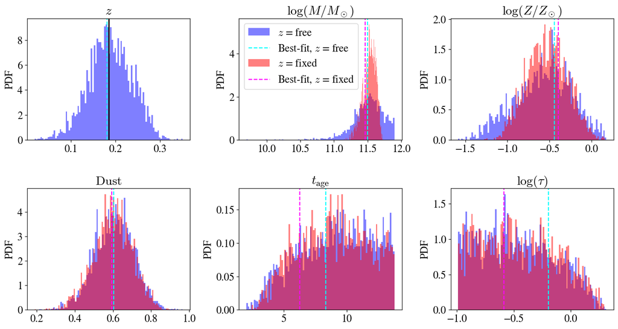

```python
# Plot a comparison of the distributions varying and not varying redshift
fig = plt.figure(figsize = (16, 8))
gs = fig.add_gridspec(2, 3, wspace = 0.3, hspace = 0.4)

# Loop over each axis
t = 0
for i in range(0, 2):
    for j in range(0, 3):

        # Add an axis to the plot
        ax = fig.add_subplot(gs[i, j])

        # Get the data for the plot
        data_Dyn = chains_Dyn[:, t]
        data_z_Dyn = chains_z_Dyn[:, t - 1]
        best_fit = theta_max[t]
        best_fit_z = theta_max_z[t - 1]

        # Add the title to the plot
        ax.title.set_text(labels[t])

        # Add the data to the plot
        if (i == 0) & (j == 0):
            ax.hist(data_Dyn, bins = 100, density = True, color = 'blue', alpha = 0.5, zorder = 1, label = '$z$ = free')
            ax.axvline(best_fit, color = 'cyan', linestyle = 'dashed', zorder = 2, label = 'Best-fit, $z$ = free')
            ax.axvline(z_red, color = 'black', linewidth = 2.0, label = 'Spec-$z$')
        else:
            ax.hist(data_Dyn, bins = 100, density = True, color = 'blue', alpha = 0.5, zorder = 1, label = '$z$ = free')
            ax.axvline(best_fit, color = 'cyan', linestyle = 'dashed', zorder = 2, label = 'Best-fit, $z$ = free')
            ax.hist(data_z_Dyn, bins = 100, density = True, color = 'red', alpha = 0.5, zorder = 1, label = '$z$ = fixed')
            ax.axvline(best_fit_z, color = 'magenta', linestyle = 'dashed', zorder = 2, label = 'Best-fit, $z$ = fixed')
        # End of if

        # Add labels to the axes
        ax.set_ylabel('PDF')

        # Add a legend
        if (i == 0) & (j == 1):
            ax.legend()

        # Iterate to next values
        t += 1

    # End of for loop
# End of for loop
```

The figure above demonstrates how the posterior distributions of the model parameters change when redshift is a free parameter vs. when it is fixed to the spectroscopic redshift measured for the galaxy. The blue distribution represents the results when redshift is a free parameter, while the red distribution shows the results when redshift is fixed. The two vertical cyan and magenta lines represent the best-fit parameters (i.e., the sample with the maximum likelihood) for each distribution.

In the top-left panel, the best-fit redshift when it is a free parameter matches up very well with the spectroscopic redshift for the galaxy. It is pretty centred with the entire posterior distribution as well.

The best-fit parameters for mass, metallicity, and dust change very little when redshift is fixed compared to when it is a free parameter. The best-fit parameters for fixed redshift shift slightly in response to the posterior distributions being more constrained. The best-fit age and $\tau$ show the largest variation between models. However, given that the posterior distributions for the fixed and free redshift models are quite broad and heavily overlap, the best-fit values are not very useful for distinguishing between models.

In Section 2, we found that the Bayes factor suggested the data preferred the fixed redshift model. However, from the results here, it is difficult to tell whether or not this conclusion is conclusive. For most of the model parameters, the best-fit values between models heavily agree. In the cases where they do not, they have very similar posteriors and the best-fit values do not summarize the posterior distributions well.

2. How do your experiences of inferring galaxy properties from MCMC compare to your inference using Machine Learning (Assignment 2 - Section 3).
- Which one was more accurate?
- What are their limitations?
- What unique infomation did the different approaches provide?

```python
# Load in the .csv file containing the ML values
ML_table = pd.read_csv('../data/gal{0}_id={1}_ML.csv'.format(gal_id, df.iloc[gal_id].id))

# Extract the ML redshift and mass
ML_red = ML_table.at[25, '101']
ML_mass = ML_table.at[24, '101']

# Extract the Chang+2015 redshift and mass
Chang_red = ML_table.at[23, '101']
Chang_mass = ML_table.at[19, '101']
```

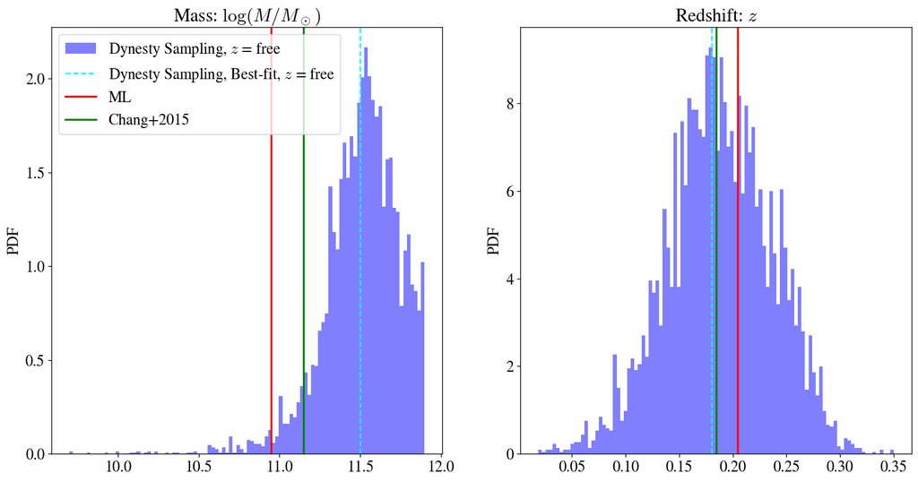

```python
# Plot the distributions for mass and redshift
fig = plt.figure(figsize = (16, 8))
gs = fig.add_gridspec(1, 2, wspace = 0.2, hspace = 0.0)

# Add an axes to the plot
ax1 = fig.add_subplot(gs[0, 0])
ax2 = fig.add_subplot(gs[0, 1])

# Add the titles to the plot
ax1.title.set_text('Mass: $\\log(M/M_\\odot)$')
ax2.title.set_text('Redshift: $z$')

# Add the mass data
ax1.hist(chains_Dyn[:, 1], bins = 100, density = True, color = 'blue', alpha = 0.5, zorder = 1, label = 'Dynesty Sampling, $z$ = free')
ax1.axvline(theta_max[1], color = 'cyan', linestyle = 'dashed', zorder = 2, label = 'Dynesty Sampling, Best-fit, $z$ = free')
ax1.axvline(ML_mass, color = 'red', linewidth = 2.0, label = 'ML')
ax1.axvline(Chang_mass, color = 'green', linewidth = 2.0, label = 'Chang+2015')
ax1.legend()

# Add the redshift data
ax2.hist(chains_Dyn[:, 0], bins = 100, density = True, color = 'blue', alpha = 0.5, zorder = 1, label = 'Dynesty Sampling, $z$ = free')
ax2.axvline(theta_max[0], color = 'cyan', linestyle = 'dashed', zorder = 2, label = 'Dynesty Sampling, Best-fit, $z$ = free')
ax2.axvline(ML_red, color = 'red', linewidth = 2.0, label = 'ML')
ax2.axvline(Chang_red, color = 'green', linewidth = 2.0, label = 'Chang+2015')

# Set the plot axes
ax1.set_ylabel('PDF')
ax2.set_ylabel('PDF')

plt.show()
```

The figure above illustrates the mass and redshift for a galaxy estimated using MCMC compared to our machine learning results from Assignment 2 and the results from Chang+2015. In the plot, the entire posterior distribution estimated using Dynesty is shown in blue, the best-fit model parameters are shown in cyan, the output of machine learning is shown in red, and the median of the posterior distribution from Chang+2015 is shown in green.

For mass, the MCMC best-fit estimate and the ML estimate are similar distances from the "true" Chang+2015 result. The ML result is slightly more accurate. However, the Chang+2015 result might not be completely accurate given that it does not overlap well with the centre of the posterior distribution.

For redshift, the three results coincide with each other well, where the MCMC best-fit estimate is slightly more accurate than the ML result. All three results are sampled from the highest probability portion of the posterior distribution.

The machine learning model we used is a decision tree model fit by associating the fluxes measured for the galaxy with the properties of the galaxy measured in Chang+2015. There are no underlying physical relationships between the input and output values. On the other hand, MCMC sampling uses a physical model to fit against defined through Prospector.

The machine learning results are much more limited than the galaxy properties inferred from MCMC. The ML results for mass and redshift are single values compared to MCMC, where we obtain estimates for the full posterior distribution of each parameter. Since we used a decision tree, the ML model will function poorly for galaxies with properties that fall outside of the training set. We do not suffer from this restriction with MCMC. One advantage to the ML model compared to MCMC is the time required for generating galaxy properties. The ML model operates much faster than MCMC sampling, and the same ML model can be used to estimate properties for each galaxy. Generating full posteriors for each galaxy using MCMC is much more computationally expensive compared to running the ML model.